# Toms River Regional School District — NJ School Data Almanac – NJ District Profiles

NJ School Data Almanac

Toms River Regional School District

OCEAN COUNTY · TRADITIONAL PUBLIC DISTRICT · DFG DE · 13,925 STUDENTS (2026)

13,925

Students

91.8%

4-yr grad rate

42.8%

Gr 3-8 ELA

15.9%

Chronically absent

$14,918

Per pupil

*9 things the data says about Toms River Regional School District. Every figure is computed from New Jersey Department of Education data via the njschooldata package — nothing is estimated. Comparisons use District Factor Group (DFG) peers (83 districts in DFG DE).*

No. 1 ACHIEVEMENT

## Toms River’s 3rd-8th-Grade Reading Scores Fell 10 Points Across COVID and Have Not Come Back

ELA proficiency in grades 3-8 dropped from 54.6% in 2019 to 44.1% in 2022 and sat at 42.8% in 2024, while math has clawed back part of its loss.

The pandemic knocked a decade’s worth of progress off Toms River’s youngest tested students, and four years later, reading has not recovered. On the NJSLA assessment for grades 3 through 8, 54.6% of Toms River students were proficient or above in English language arts in 2019. By 2022 that share had fallen to 44.1%, a drop of 10.5 percentage points, and rather than rebounding it slid again to 42.4% in 2023 before edging up to just 42.8% in 2024 — still nearly 12 points below the pre-pandemic mark.

Math tells a more hopeful story. Proficiency there was already lower, at 36.9% in 2019, and it fell harder during the disruption, to 26.5% in 2022. But unlike reading, math has climbed back, reaching 27.6% in 2023 and 30.8% in 2024, recovering roughly four of the ten points it lost.

The divergence is striking: the subject that fell less has stalled, while the subject that fell more is healing. With ELA proficiency now stuck below 43% across grades 3-8, the question for Toms River is why reading recovery has flatlined where math intervention appears to be working, and whether the youngest cohorts who learned to read during the closures are carrying that gap forward.

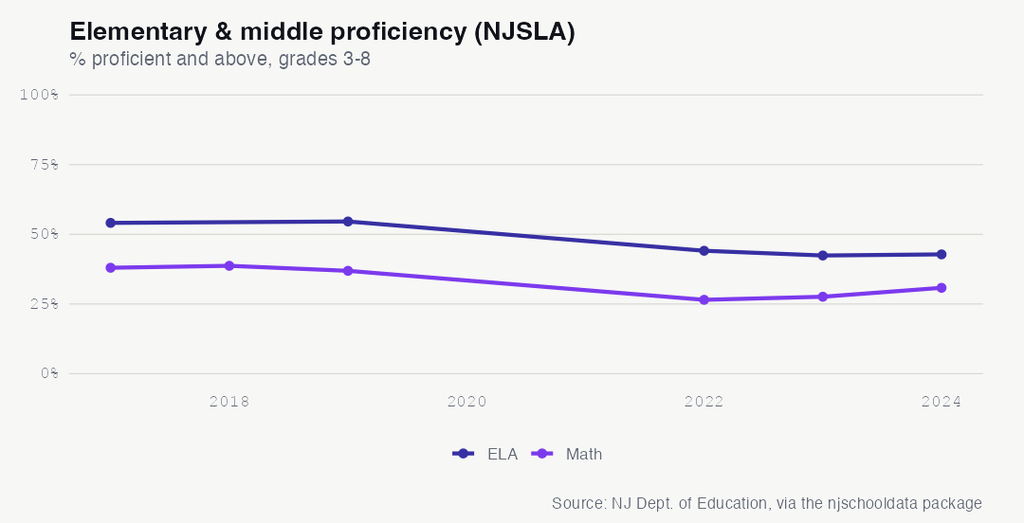

See the underlying data ›

No. 2 FINANCE

## Toms River Spends $14,918 Per Student, in the 2nd Percentile of Its 83 Peer Districts as Poverty Nears Half the District

Per-pupil spending sits about $4,000 below the District Factor Group median even as the share of students eligible for subsidized lunch climbed to 46.5%.

Among the 83 districts in its District Factor Group (DFG DE), Toms River Regional is one of the leanest-spending in the state. Its 2024 per-pupil spending of $14,918 placed the district in just the 2nd percentile of that group, where the median district spent $18,964 — a gap of roughly $4,000 per student. Across a district of nearly 14,000 students, that difference compounds into a very different budget than its socioeconomic peers carry.

The gap persists even though Toms River’s own spending has grown, from $11,746 in 2014 to $14,918 in 2024, a 27.0% increase. The peer group simply spent more, and faster. Meanwhile the students that budget serves have grown markedly needier: the share eligible for free or reduced-price lunch rose from 28.5% in 2015 (4,498 students) to 46.5% in 2026 (6,475 students), an 18-percentage-point jump, with most of it arriving after 2023.

Where the dollars go leans toward classrooms — 59.3% of 2025 spending went to instruction, with 15.9% to support services, 10.7% to plant operations, and 9.9% to administration. The board’s question is unavoidable: can an instruction-heavy budget this far below its peers absorb a poverty rate that has climbed toward half the district in just a few years?

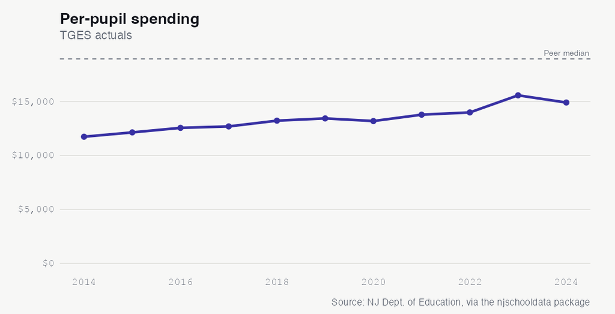

See the underlying data ›

No. 3 EQUITY

## In Toms River, 49% of White 3rd-8th Graders Read Proficiently — But Only 24% of Black Students Do

Toms River’s 2024 reading results for grades 3 through 8 fan out into a wide spread by subgroup. At the top, 69.6% of Asian students were proficient or above in ELA, well ahead of the district’s 42.8% overall. White students followed at 49.3% and female students at 48.9%, both above the district line.

These are not unusual patterns for New Jersey, but the breadth — from 69.6% down to under 3% — defines the equity challenge in the district’s elementary and middle grades. The question Toms River’s data raises is which of these gaps the recovery effort reaches first, given that the lowest-scoring groups are also among the fastest-growing parts of the district.

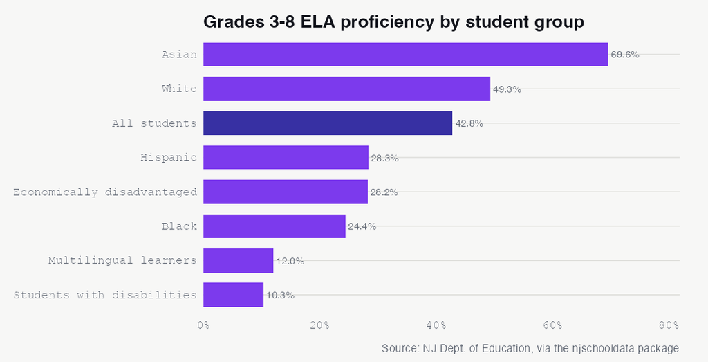

See the underlying data ›

No. 4 DEMOGRAPHICS

White students dropped 19.4 percentage points over 11 years while the Hispanic share rose from 12.9% to 29.6%.

The counterweight is rising Hispanic enrollment, which climbed from 12.9% in 2015 to 29.6% in 2026, a gain of 16.7 percentage points. Hispanic students now make up close to a third of the district. Smaller shifts accompanied the change: the multiracial share grew from 2.2% to 4.5%, Black enrollment edged up from 4.8% to 5.9%, and the Asian share held roughly flat near 3.3%.

The district has also become far more multilingual: students classified as English learners climbed from 162 in 2015 (1.0% of enrollment) to 989 in 2026 (7.1%), more than a sixfold increase in raw count. As Toms River plans staffing, language services, and facilities, the question is whether the pace of white decline levels off near its current share or continues downward through the rest of the decade.

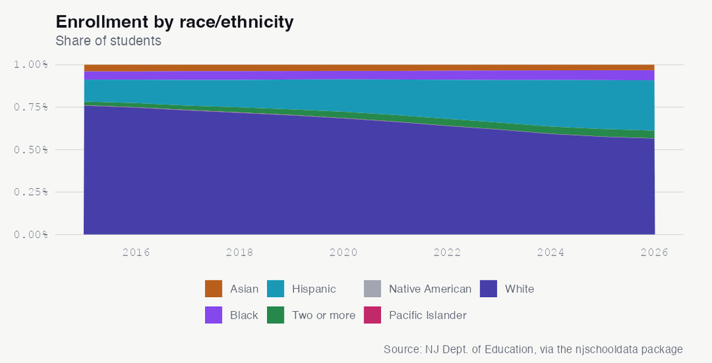

See the underlying data ›

No. 5 GRADUATION

## Toms River’s Graduation Rate of 91.8% Ranks in the 19th Percentile Among Its Peer Districts

After sliding to 87.9% in 2024, the district’s four-year graduation rate rebounded but still trails the peer median of 93.8%.

Toms River Regional graduated 91.8% of its 2025 four-year cohort of 1,261 students — a rebound, but one that still leaves the district in the 19th percentile among the 83 districts in its District Factor Group, where the median rate is 93.8%. The roughly two-point gap means most of Toms River’s socioeconomic peers graduate a larger share of their students.

The 2025 figure followed several years of decline. The rate fell from 92.2% in 2020 to 90.6% in 2021, 89.8% in 2022, 89.5% in 2023, and bottomed at 87.9% in 2024 before recovering nearly four points in a single year. That kind of rebound after a multi-year slide is notable, though it leaves the district roughly where it stood at the start of the decade.

With graduation tied to so much of a district’s reputation and its students’ futures, the question is whether the 2025 recovery marks a durable turnaround or a one-year bounce after the 2024 trough.

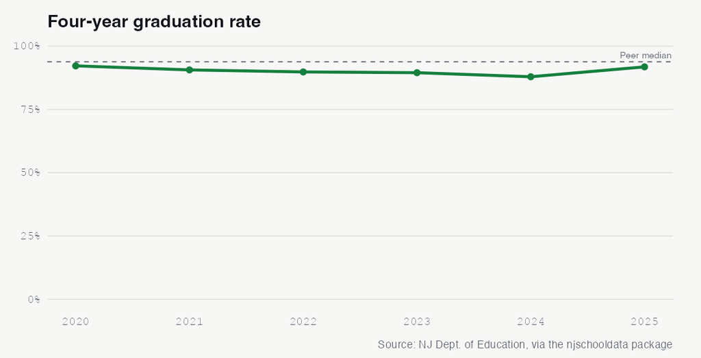

See the underlying data ›

No. 6 EQUITY

## Toms River Students Experiencing Homelessness Graduated at 65.6% in 2025, 29 Points Below White Peers

Four-year graduation ranged from 97.8% for Asian students down to 65.6% for students experiencing homelessness.

Toms River’s strongest graduating groups in 2025 cleared the bar at high rates: 97.8% of Asian students and 94.2% of white students earned a diploma in four years, both above the district’s overall 91.8%. Female students graduated at 94.0%, edging out male students at 89.8%.

These gaps are not unique to Toms River, but the spread from 97.8% down to 65.6% is wide. The question they raise is which of these groups the district’s lean budget can move first, and how quickly.

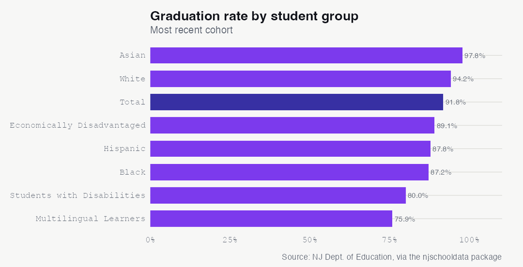

See the underlying data ›

No. 7 ATTENDANCE

## Toms River’s Chronic Absenteeism Sits at 15.9%, Above the Peer Median and Its Own Pre-COVID Rate

After peaking near 22% during the pandemic, the share of chronically absent students has eased but remains well above its 12.1% 2019 baseline.

Before the pandemic, 12.1% of Toms River students were chronically absent in 2019 — meaning they missed at least 10% of school days. By 2024 the rate stood at 15.9%, above the peer-group median of 13.6% and still well above the district’s own pre-COVID level.

The path between those years was turbulent. The rate dipped to 10.5% in 2021, a year of disrupted attendance counting, then more than doubled to 21.0% in 2022 and edged up to 21.7% in 2023 before falling sharply to 15.9% in 2024. That recovery from the peak is real, cutting the rate by nearly six points in a single year, but it has not yet returned the district to where it was in 2019.

Chronic absence is closely linked to academic outcomes, and Toms River’s rate sitting above its peer median is a flag for a district that already spends near the bottom of its group. Whether attendance continues drifting back toward its pre-pandemic level or settles at this elevated plateau is the trend to watch.

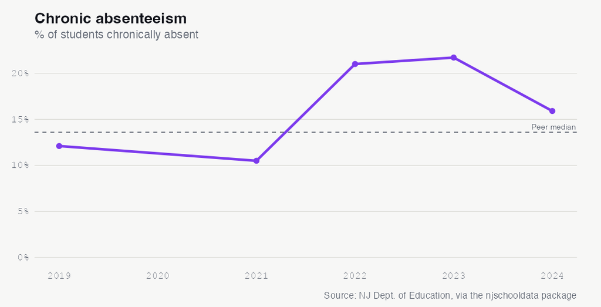

See the underlying data ›

No. 8 ACHIEVEMENT

## Toms River Students Pass NJGPA English at 78.8% but Math at Just 47.7%

On the state’s graduation-proficiency test, fewer than half of Toms River 11th graders met the bar in math in 2025.

On the NJGPA, New Jersey’s high-school graduation-proficiency assessment, Toms River students show a sharp split between subjects. In 2025, 78.8% of test-takers were proficient or above in English language arts, but only 47.7% cleared the bar in math — a gap of more than 31 percentage points among the same group of roughly 1,200 students.

Both subjects dipped from the prior year. ELA proficiency had reached 84.1% in 2024 before falling to 78.8% in 2025, while math slipped from 49.1% to 47.7%. Math has trailed badly across all three years of data, never rising above 49.1%, while ELA has stayed in the 75-to-84% range.

The subject split mirrors what shows up six grades earlier: on the NJSLA for grades 3-8, math proficiency has also lagged ELA for years. A math proficiency rate below 50% on a test tied to graduation is a flag worth watching. The question is whether the math gap reflects the test, the curriculum, or weaknesses in earlier grades that surface only when students reach the 11th-grade assessment.

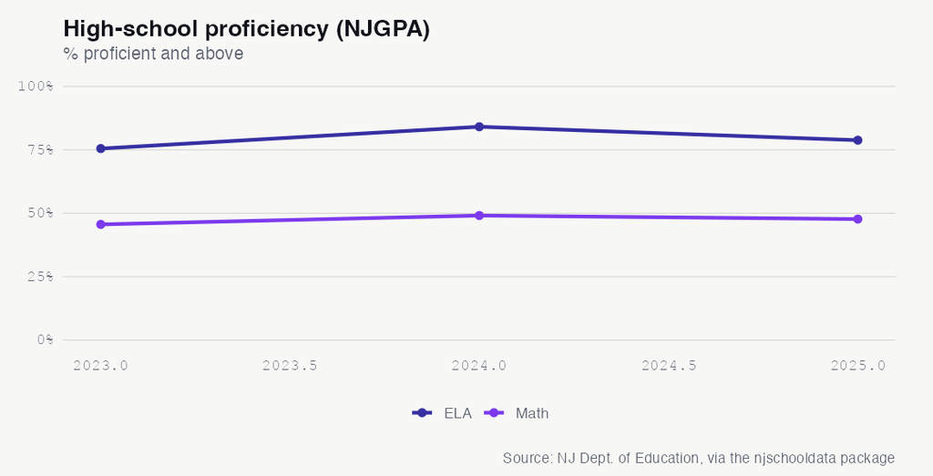

See the underlying data ›

No. 9 ENROLLMENT

## Toms River Enrollment Has Fallen to 13,925, the Lowest on Record and Down 12% Since 2015

The district has shed 1,834 students since 2015, including an 825-student drop across the pandemic years.

Toms River Regional now enrolls 13,925 students, its lowest figure on record and down 11.6% from 15,759 in 2015. After peaking at 15,934 in 2017, enrollment has declined nearly every year since, with the steepest single-year drop coming in 2021, when the district lost 674 students.

The pandemic left a clear mark. Between 2019 and 2022, enrollment fell by 825 students, a 5.4% decline, and unlike some districts that bounced back, Toms River has continued to shrink. The most recent two years brought losses of 172 and 193 students, keeping the downward trend intact through 2026.

Declining enrollment reshapes everything from staffing to state aid to building use. With the district already spending near the bottom of its peer group, the question is how a shrinking student body interacts with a budget that has little room to give.

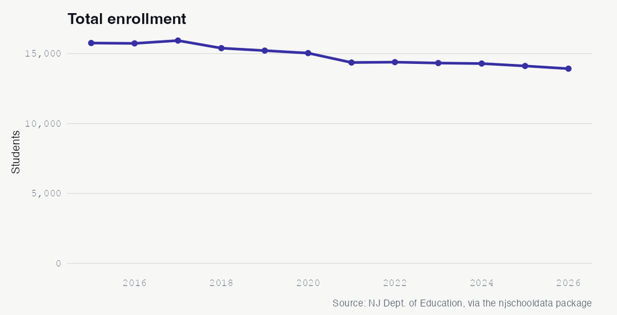

See the underlying data ›

## The Almanac

The full longitudinal record behind the stories above. Every number a reader can check.

### Enrollment (total)

| year | students | yoy | yoy_pct |
| --- | --- | --- | --- |
| 2015 | 15759 | NA | NA |
| 2016 | 15732 | -27 | -0.2 |
| 2017 | 15934 | 202 | 1.3 |
| 2018 | 15392 | -542 | -3.4 |
| 2019 | 15216 | -176 | -1.1 |
| 2020 | 15038 | -178 | -1.2 |
| 2021 | 14364 | -674 | -4.5 |
| 2022 | 14391 | 27 | 0.2 |
| 2023 | 14326 | -65 | -0.5 |
| 2024 | 14290 | -36 | -0.3 |
| 2025 | 14118 | -172 | -1.2 |
| 2026 | 13925 | -193 | -1.4 |

### Demographic share (%) by year

| end_year | white | black | hispanic | asian | native_american | pacific_islander | multiracial |
| --- | --- | --- | --- | --- | --- | --- | --- |
| 2015 | 75.9 | 4.8 | 12.9 | 3.9 | 0.1 | 0.1 | 2.2 |
| 2016 | 74.7 | 4.8 | 13.8 | 4 | 0.1 | 0.1 | 2.4 |
| 2017 | 73.1 | 5.2 | 15.1 | 3.8 | 0.1 | 0.2 | 2.6 |
| 2018 | 71.6 | 5.1 | 16.2 | 3.8 | 0.1 | 0.2 | 3 |
| 2019 | 70.2 | 5 | 17.6 | 3.7 | 0.1 | 0.1 | 3.3 |
| 2020 | 68.4 | 5 | 19.1 | 3.7 | 0 | 0.1 | 3.7 |
| 2021 | 66.3 | 5 | 20.9 | 3.7 | 0 | 0.1 | 3.9 |
| 2022 | 63.9 | 5.3 | 23 | 3.5 | 0.1 | 0.1 | 4.1 |
| 2023 | 61.8 | 5.6 | 25.1 | 3.4 | 0 | 0.1 | 4 |
| 2024 | 59.2 | 5.6 | 27.4 | 3.3 | 0.1 | 0.1 | 4.3 |
| 2025 | 57.6 | 5.8 | 28.8 | 3.3 | 0 | 0.1 | 4.4 |
| 2026 | 56.5 | 5.9 | 29.6 | 3.3 | 0 | 0.1 | 4.5 |

### Special populations (LEP, FRL)

| end_year | subgroup | students | pct |
| --- | --- | --- | --- |
| 2015 | lep | 162 | 1.0 |
| 2015 | free_reduced_lunch | 4498 | 28.5 |
| 2016 | lep | 232 | 1.5 |
| 2016 | free_reduced_lunch | 4616 | 29.3 |
| 2017 | lep | 190 | 1.2 |
| 2017 | free_reduced_lunch | 4606 | 28.9 |
| 2018 | lep | 238 | 1.5 |
| 2018 | free_reduced_lunch | 4435 | 28.8 |
| 2019 | lep | 255 | 1.7 |
| 2019 | free_reduced_lunch | 4450 | 29.2 |
| 2020 | lep | 271 | 1.8 |
| 2020 | free_reduced_lunch | 4707 | 31.3 |
| 2021 | lep | 287 | 2.0 |
| 2021 | free_reduced_lunch | 4065 | 28.3 |
| 2022 | lep | 389 | 2.7 |
| 2022 | free_reduced_lunch | 4360 | 30.3 |
| 2023 | lep | 573 | 4.0 |
| 2023 | free_reduced_lunch | 4542 | 31.7 |
| 2024 | lep | 772 | 5.4 |
| 2024 | free_reduced_lunch | 5316 | 37.2 |
| 2025 | lep | 988 | 7.0 |
| 2025 | free_reduced_lunch | 6296 | 44.6 |
| 2026 | lep | 989 | 7.1 |
| 2026 | free_reduced_lunch | 6475 | 46.5 |

### Graduation rate 4yr (total)

| year | grad_rate | cohort |
| --- | --- | --- |
| 2020 | 92.2 | 1223 |
| 2021 | 90.6 | 1219 |
| 2022 | 89.8 | 1271 |
| 2023 | 89.5 | 1209 |
| 2024 | 87.9 | 1289 |
| 2025 | 91.8 | 1261 |

### Graduation by subgroup (2025)

| subgroup | grad_rate | cohort |
| --- | --- | --- |
| asian | 97.8 | 45 |
| white | 94.2 | 724 |
| female | 94.0 | 615 |
| total | 91.8 | 1261 |
| male | 89.8 | 646 |
| multiracial | 89.2 | 37 |
| economically disadvantaged | 89.1 | 586 |
| hispanic | 87.8 | 369 |
| black | 87.2 | 86 |
| students with disabilities | 80.0 | 240 |
| multilingual learners | 75.9 | 79 |
| students experiencing homelessness | 65.6 | 32 |
| american indian | NA | NA |
| migrant students | NA | NA |
| military-connected students | NA | NA |
| non-binary/undesignated gender | NA | NA |
| students in foster care | NA | NA |

### NJGPA high-school proficiency (% proficient+)

| year | test | prof_above | valid |
| --- | --- | --- | --- |
| 2023 | ela | 75.5 | 1157 |
| 2023 | math | 45.6 | 1177 |
| 2024 | ela | 84.1 | 1194 |
| 2024 | math | 49.1 | 1194 |
| 2025 | ela | 78.8 | 1200 |
| 2025 | math | 47.7 | 1200 |

### NJGPA ELA by subgroup (2025)

[output not shown]

### NJSLA grades 3-8 proficiency (% proficient+, enrollment-weighted across grades)

| testing_year | test_name | prof |
| --- | --- | --- |
| 2017 | ela | 54.1 |
| 2017 | math | 38.0 |
| 2018 | math | 38.7 |
| 2019 | ela | 54.6 |
| 2019 | math | 36.9 |
| 2022 | ela | 44.1 |
| 2022 | math | 26.5 |
| 2023 | ela | 42.4 |
| 2023 | math | 27.6 |
| 2024 | ela | 42.8 |
| 2024 | math | 30.8 |

### NJSLA ELA proficiency by subgroup (2024, grades 3-8)

| subgroup | prof |
| --- | --- |
| asian | 69.6 |
| non_ed | 51.5 |
| white | 49.3 |
| female | 48.9 |
| total_population | 42.8 |
| other | 42.1 |
| male | 36.8 |
| FORMER - ML | 29.0 |
| hispanic | 28.3 |
| ed | 28.2 |
| black | 24.4 |
| lep_former | 21.4 |
| lep_current_former | 12.3 |
| MULTILINGUAL LEARNERS | 12.0 |
| special_education | 10.3 |
| sped_accomodations | 7.9 |
| CURRENT - ML | 4.3 |
| lep_current | 2.9 |

### Chronic absenteeism (% chronically absent)

| year | chronic_pct |
| --- | --- |
| 2019 | 12.1 |
| 2021 | 10.5 |
| 2022 | 21 |
| 2023 | 21.7 |
| 2024 | 15.9 |

### Disciplinary removals

[output not shown]

### Police notifications (incident counts)

| year | violence | weapons | vandalism | substances | hib | other |
| --- | --- | --- | --- | --- | --- | --- |
| 2019 | 53 | 14 | 14 | 19 | 18 | 3 |
| 2020 | 38 | 7 | 13 | 28 | 1 | 6 |
| 2021 | 6 | 2 | 1 | 4 | 1 | 0 |
| 2022 | 59 | 17 | 14 | 57 | 7 | 3 |
| 2023 | 62 | 17 | 12 | 74 | 2 | 0 |
| 2024 | 34 | 7 | 7 | 60 | 8 | 1 |

### HIB (harassment/intimidation/bullying) investigations

| end_year | alleged | confirmed |
| --- | --- | --- |
| 2019 | 188 | 104 |
| 2020 | 114 | 77 |
| 2021 | 53 | 27 |
| 2022 | 194 | 141 |
| 2023 | 242 | 148 |
| 2024 | 201 | 115 |

### SAT participation (% of grade)

| year | sat_part | state_sat |
| --- | --- | --- |
| 2018 | 66.9 | 72.2 |
| 2019 | 61.6 | 72.1 |
| 2020 | 56.1 | 71.1 |
| 2021 | 36.6 | 45.4 |
| 2022 | 47.6 | 60.8 |
| 2023 | 49.8 | 61.9 |
| 2024 | 41.2 | 62.7 |

### AP/IB & dual enrollment (% of students)

| year | apib_coursework | apib_exam | ap3_ib4 | state_ap3_ib4 | dual |
| --- | --- | --- | --- | --- | --- |
| 2018 | 34.5 | 33.6 | 22.7 | 20.5 | 0 |
| 2019 | 34.6 | 34.1 | 21.1 | 20.7 | 0 |
| 2020 | 32.9 | 33.1 | 26.2 | 22.8 | 0 |
| 2021 | 34.7 | 34.1 | 17.2 | 17.9 | 27.2 |
| 2022 | 30.6 | 30.1 | 21.4 | 19.9 | 72.5 |
| 2023 | 32.2 | 31.2 | 21.8 | 21.3 | 71 |
| 2024 | 29.7 | 30 | 22.7 | 23 | 59.9 |

### Special education (raw rows; inspect for classification rate)

| end_year | district_id |
| --- | --- |
| 2024 | 5190 |

### Per-pupil spending (TGES actuals)

| year | per_pupil | rank | ade |
| --- | --- | --- | --- |
| 2014 | 11746 | 7 | 16134 |
| 2015 | 12148 | 10 | 15784 |
| 2016 | 12567 | 14 | 15812 |
| 2017 | 12701 | 12 | 15603 |
| 2018 | 13235 | 14 | 15399 |
| 2019 | 13445 | 7 | 15255 |
| 2020 | 13201 | 4 | 15040 |
| 2021 | 13789 | 3 | 14367 |
| 2022 | 13999 | 1 | 14403 |
| 2023 | 15584 | 7 | 14359 |
| 2024 | 14918 | 2 | 14281 |

### Spending composition shares (2025)

| classroom_share | support_services_share | administration_share | plant_ops_share | food_service_share | extracurricular_share | equipment_share |
| --- | --- | --- | --- | --- | --- | --- |
| 59.3 | 15.9 | 9.9 | 10.7 | NA | 2.2 | 0.1 |

### Staffing ratios

| end_year | student_teacher_district | student_admin_district | student_counselor_district | student_nurse_district |
| --- | --- | --- | --- | --- |
| 2024 | 13:1 | 219:1 | 344:1 | 466:1 |

Back to top